# Mixed effect stock valuation

Brent Morrison

2022-02-22

> *“datasets are often highly structured, containing clusters of non-independent observational units that are hierarchical in nature, and Linear Mixed Models allow us to explicitly model the non-independence in such data”*  
> (Harrison et al., 2018)[1]

> *They allow modeling of data measured on different levels at the same time – for instance students nested within classes and schools – thus taking complex dependency structures into account*  
> (Bürkner, 2018)[2]

> *These models inherently regularize estimates towards a central value to an extent that depends on the heterogeneity of the underlying groups.*  
> (Green & Thomas, 2019)[3]

> *The regularizing aspects of the ‘partial pooling’ inherent in the structure of these models (averaging parameter estimates between in-group and across-subject loadings) help to mitigate the impacts of multiple comparisons by pulling an estimate towards its central tendency to the extent warranted by the between-group variance*  
> (Green & Thomas, 2019)[3]

An investigation into stock valuation using regression models. We will use a couple of different techniques. Ordinary least squares, multi-levels models (estimated using both frequentist and bayesian approaches), and robust regression.

The valuation model is the [P/B - ROE model](https://papers.ssrn.com/sol3/papers.cfm?abstract_id=534442). This model relates the ratio of market capitalisation over book value to return on equity. We expect that the slope of the regression co-efficient is positive, indicating that holding book value constant, a higher ROE leads to higher valuation.

As alluded to in the quotes above, the focus will be on multi-level models. Why? Multi-level models purport to provide more robust results by virtue of partial pooling. Partial pooling results in regularisation of parameter estimates. Robust regression techniques also purport to provide robust results (it’s all in the name isn’t it). Why not see how they compare.

The Theil-Sen regression, which has been discussed [here](https://brentmorrison.netlify.app/post/abalone-and-outliers/) is a robust technique and works to dampen the impact of outliers. It does so whereby the slope is derived taking the median of many individual slopes, that being fitted to each pair of data points.

Two approaches that have a similar aim. It will be interesting to review the difference in fit between models that pool data, and those that use robust techniques.

```r
# Libraries
library(tidyverse)
library(DBI)
library(RPostgres)
library(DescTools)
library(lubridate)
library(mblm)
library(romerb)
library(recipes)
library(lme4)
library(rethinking)
library(brms)
library(DT)

data("stock_data")
fundamental_raw <- stock_data
rm(stock_data)

# Set default theme
def_theme1 <- theme_minimal() +
  theme(
    legend.title = element_blank(),
    legend.position = c(0.9,0.9),
    legend.background = element_blank(),
    legend.key = element_blank(),
    plot.caption = element_text(size = 8, color = "grey55", face = 'italic'),
    axis.title.y = element_text(size = 8, color = "darkslategrey"),
    axis.title.x = element_text(size = 8, color = "darkslategrey"),
    axis.text.y = element_text(size = 7, color = "darkslategrey"),
    axis.text.x = element_text(size = 7, color = "darkslategrey")
    )
```

## The data

The data comprises around 750 individual companies. These companies are grouped into 11 sectors and 40 odd industries. The data is as of June 2021 and comes from the Securites and Exchange Commission via my Stock_master database.

Below are the variables of interest.

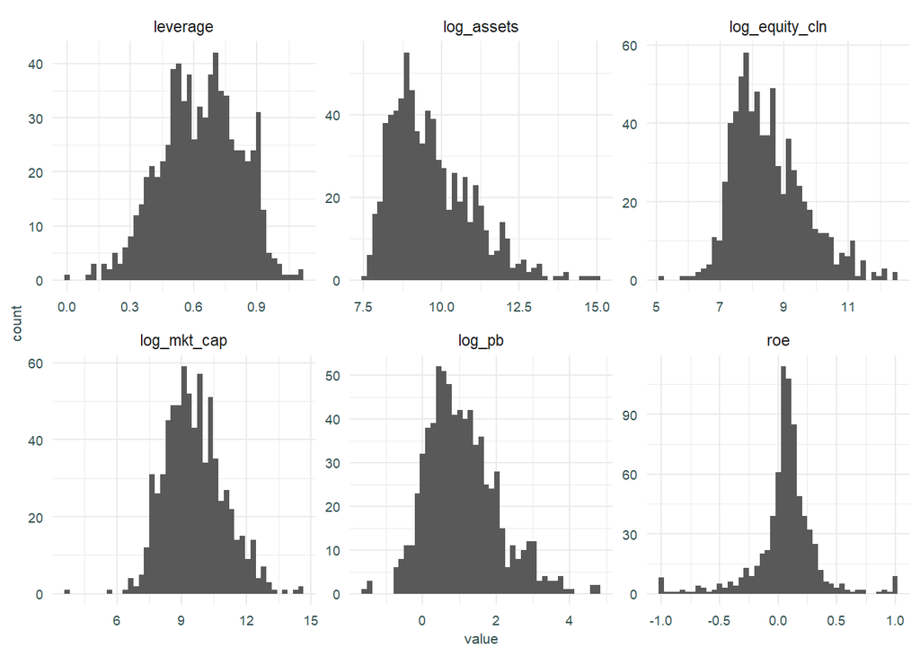

```r
data <- fundamental_raw %>%
  filter(date_stamp == as.Date('2021-06-30')) %>%
  mutate(
    log_mkt_cap = log(mkt_cap),
    log_assets = log(total_assets),
    log_equity_cln = log(-total_equity_cln),
    roe = -roe,
    roe_s = scale(roe),
    leverage_s = scale(leverage),
    sector = as.factor(sector),
    industry = as.factor(industry)
  ) %>%
  select(date_stamp, symbol, log_mkt_cap, log_assets, log_equity_cln, roe, roe_s, leverage, leverage_s, vol_ari_60d, sector, industry, log_pb)

data %>%
  pivot_longer(
    cols = c(log_pb, log_mkt_cap, roe, log_assets, log_equity_cln, leverage),
    names_to = 'attribute',
    values_to = 'value'
    ) %>%
  ggplot(aes(value)) +
  geom_histogram(bins = 45) +
  facet_wrap(vars(attribute), scales = 'free') +
  def_theme1
```

## Aggregate analysis

The plot below shows the relationship between the log price/book ratio and ROE for all stocks regardless of sector or industry membership. The blue line is the regression line fitted using OLS, the grey line that fitted using the Theil-Sen robust estimator, and magenta is a GAM smooth.

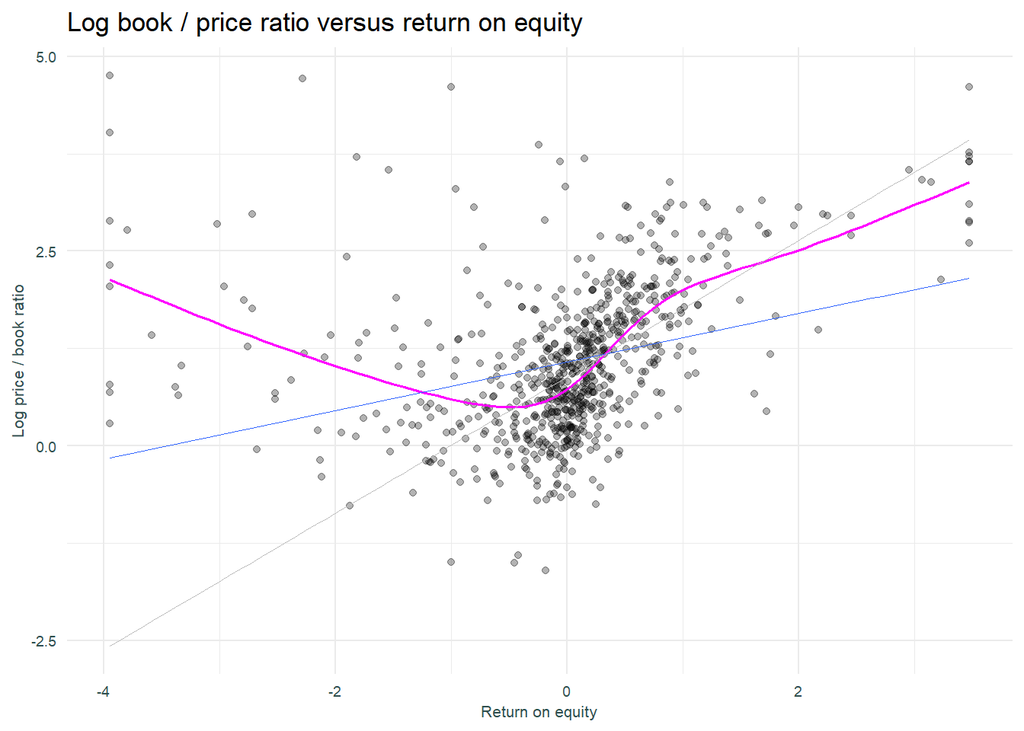

```r
# For Theil Sen line https://stackoverflow.com/questions/48349858/how-can-i-use-theil-sen-method-with-geom-smooth
sen <- function(..., weights = NULL) {
  mblm::mblm(...)
}

data %>%
  ggplot(aes(x = roe_s, y = log_pb)) +
  geom_point(alpha = 0.3) +
  stat_smooth(method = 'gam', se = FALSE, formula = y ~ s(x), size = 0.6, colour = 'magenta') +
  geom_smooth(method = lm, se = FALSE, size = 0.3, color = "#3366FF") +
  geom_smooth(method = sen, se = FALSE, size = 0.3, colour = 'grey') +
  labs(
    title = 'Log book / price ratio versus return on equity',
    x = 'Return on equity',
    y = 'Log price / book ratio'
  ) +
  theme(
    plot.caption = element_text(size = 8, margin = margin(t = 10), color = "grey40", hjust = 0),
    axis.text.x = element_blank(),
    axis.text.y = element_blank(),
    axis.ticks = element_blank()
  ) +
  def_theme1
```

The Theil-Sen regression seems to fit the data better (at least on a rough eyeballing of the plot), fitting the dense cluster of data points more closely. As expected, the slope of the line is positive, indicating all else equal a higher valuation given higher return on equity.

There is a hint of non-linearity in the relationship.

## Sector analysis 1

Stocks with similar characteristics are grouped into sectors.

The plot below shows the same regression models estimated above (the GAM has been removed), except now applied individually to each sector.

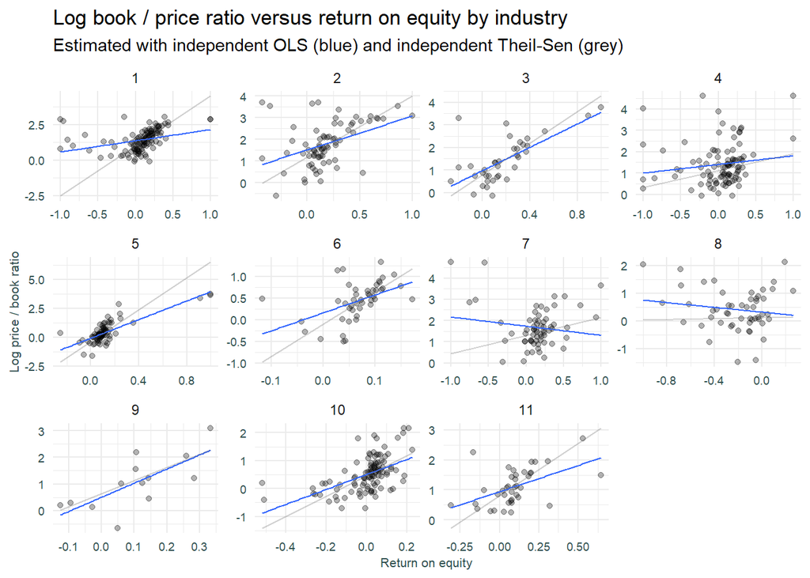

```r
# Model coefficients for OLS and Thiel Sen regression
model_coefs <- data %>%
  group_by(date_stamp, sector) %>%
  filter(n() > 1) %>%
  nest() %>%
  mutate(
    fit_ols = purrr::map(.x = data, .f = ~lm(log_pb ~ roe, data = .x)),
    fit_ts = purrr::map(.x = data, .f = ~mblm(log_pb ~ roe, data = .x, repeated = TRUE)),
    int_ols = purrr::map_dbl(.x = fit_ols, .f = function(x) coef(summary(x))['(Intercept)', 'Estimate']),
    slp_ols = purrr::map_dbl(.x = fit_ols, .f = function(x) coef(summary(x))['roe', 'Estimate']),
    int_ts = purrr::map_dbl(.x = fit_ts, .f = function(x) coef(summary(x))['(Intercept)', 'Estimate']),
    slp_ts = purrr::map_dbl(.x = fit_ts, .f = function(x) coef(summary(x))['roe', 'Estimate']),
    x_min = purrr::map_dbl(.x = data, .f = ~min(.x$roe)),
    x_max = purrr::map_dbl(.x = data, .f = ~max(.x$roe)),
    y_min = int_ts + slp_ts * x_min,
    y_max = int_ts + slp_ts * x_max
  ) %>%
  select(-fit_ols, -fit_ts, -data) %>%
  ungroup()

# Plot
p1 <- data %>%
  ggplot(aes(x = roe, y = log_pb)) +
  facet_wrap(~reorder(sector, as.numeric(sector)), ncol = 4, scales = 'free') +
  geom_point(alpha = 0.3) +
  geom_smooth(method = lm, se = FALSE, size = 0.4, color = "#3366FF") +
  geom_segment(
    aes(x = x_min, xend = x_max, y = y_min, yend = y_max),
    alpha = 0.3,
    data = filter(model_coefs, date_stamp == as.Date('2021-06-30')),
    colour = 'grey40'
  ) +
  labs(
    title = 'Log book / price ratio versus return on equity by industry',
    subtitle = 'Estimated with independent OLS (blue) and independent Theil-Sen (grey)',
    x = 'Return on equity',
    y = 'Log price / book ratio'
  ) +
  def_theme1

p1
```

Once again we might argue the robust regression fits the data better. Witness group 1 comprising the “Industrials” sector, whereby the data points distinct from the diagonal cluster, skews the fit.

Below, the intercepts and slopes for each of the individual linear models are plotted.

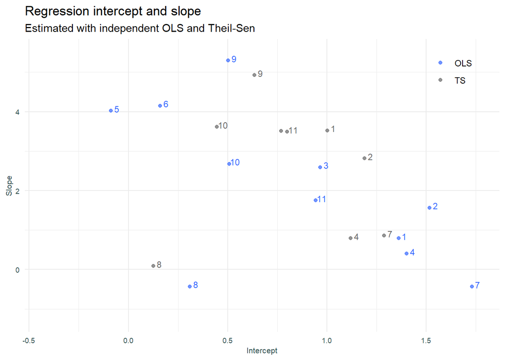

```r
model_coefs_all <- bind_rows(
  data.frame(
    sector = as.factor(model_coefs$sector),
    intercept = model_coefs$int_ols,
    slope = model_coefs$slp_ols,
    source = rep("OLS", 11)
    ),
  data.frame(
    sector = as.factor(model_coefs$sector),
    intercept = model_coefs$int_ts,
    slope = model_coefs$slp_ts,
    source = rep("TS", 11)
    )
  )

model_coefs_all %>%
  filter(source %in% c('OLS','TS')) %>%
  ggplot(aes(x = intercept, y = slope, colour = source)) +
  geom_point(alpha = 0.7) + ylim(-1.25, 5.5) +
  geom_text(aes(label = sector), nudge_x = 0.03, nudge_y = 0.05, check_overlap = TRUE, show.legend = FALSE, size = 3) +
  labs(
    title = 'Regression intercept and slope',
    subtitle = 'Estimated with independent OLS and Theil-Sen',
    x = 'Intercept',
    y = 'Slope'
  ) +
  def_theme1 +
  scale_color_manual(values=c("OLS"="#3366FF", "TS"="grey40"))
```

A couple of the OLS models have negative slopes and consistent with the observations above, the Theil-Sen slopes are more compact or closer to each other.

## Sector analysis 2

We now add a Least Squares Dummy Variable regression. The plot below is presented with fixed scales to demonstrate the identical slopes that the LSDV structure enforces.

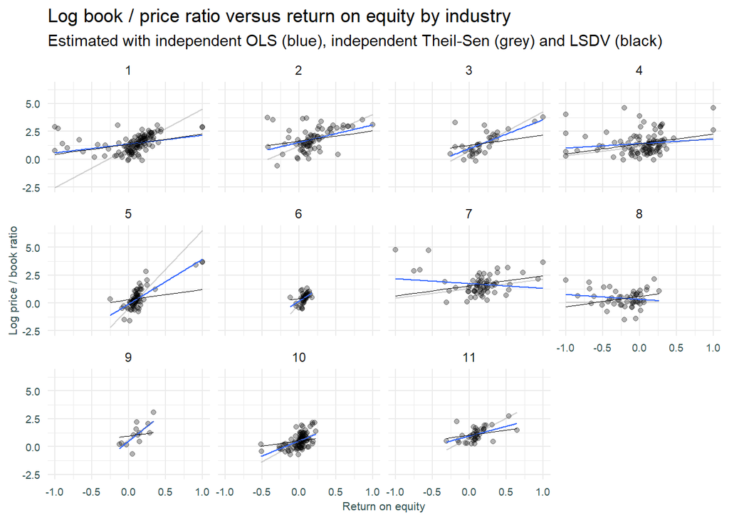

```r
data1 <- data %>%
  select(date_stamp, sector, log_pb, log_mkt_cap, roe, log_assets, log_equity_cln, leverage)

rec <- recipe(log_pb ~ roe + sector, data = data1)

lsdv_data <- rec %>% step_dummy(sector, keep_original_cols = TRUE) %>% prep(training = data) %>% bake(new_data = NULL)

lsdv_mdl <- lm(log_pb ~ roe + sector_X2 + sector_X3 + sector_X4 +
               sector_X5 + sector_X6 + sector_X7 + sector_X8 +
               sector_X9 + sector_X10 + sector_X11,
               data = lsdv_data)

lsdv_data$lsvd_pred <- predict(lsdv_mdl)
data$lsvd_pred <- lsdv_data$lsvd_pred

# Plot
p2 <- p1 +
  geom_line(aes(x = roe, y = lsvd_pred), data = lsdv_data, size = 0.3, color = "black") +
  labs(subtitle = 'Estimated with independent OLS (blue), independent Theil-Sen (grey) and LSDV (black)') +
  facet_wrap(~reorder(sector, as.numeric(sector)), ncol = 4, scales = 'fixed') +
  def_theme1

p2
```

The plot is a little harder to read with the constant scale. We can see however that the LSDV forces an unnatural fit. Sector 5 for example, (Financial Services) has a much smaller slope than would appear warranted. This is driven by the influence of other sectors that have a large slope. Financials are in effect an outlier among sectors and the rigidity of the model does not allow the data to influence this sectors slope.

Intercepts and slopes for individual linear models by sector, and the LSDV model.

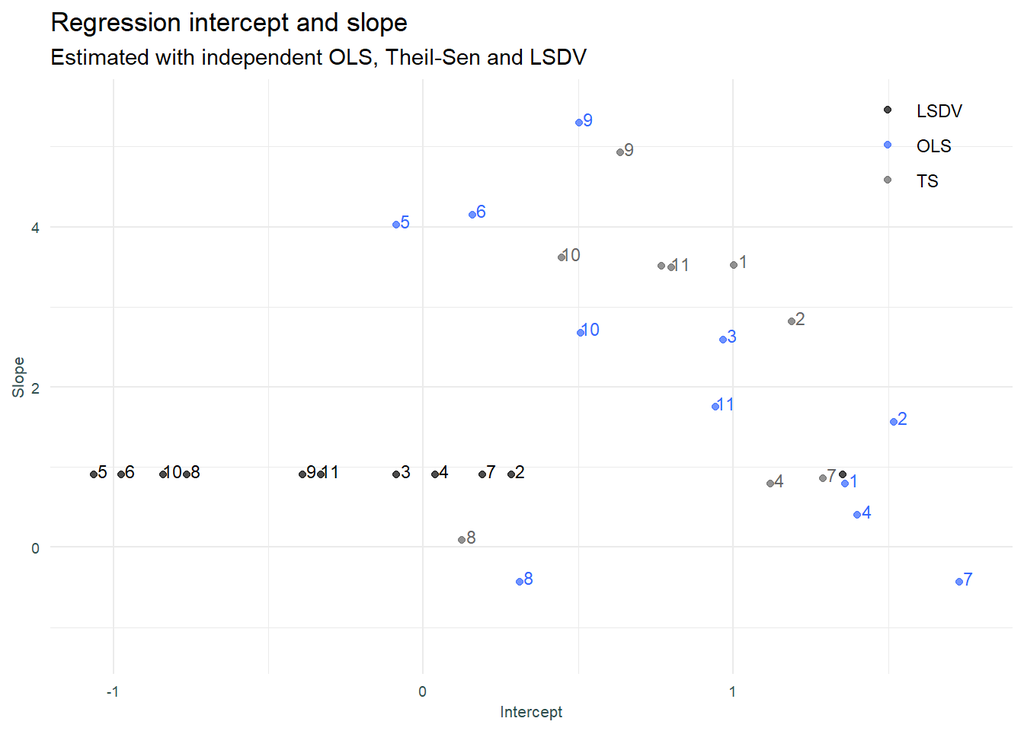

```r
lsdv_mdl_coef <- as.data.frame(coef(lsdv_mdl)) %>%
  rownames_to_column(var = 'intercept') %>%
  mutate(slope = unname(coef(lsdv_mdl)['roe']))
lsdv_mdl_coef[1, 1] <- 1
lsdv_mdl_coef <- lsdv_mdl_coef[lsdv_mdl_coef$intercept != 'roe', ]
lsdv_mdl_coef$intercept <- as.factor(gsub("[^0-9.]", "",  lsdv_mdl_coef$intercept))
lsdv_mdl_coef$source <- 'LSDV'
names(lsdv_mdl_coef)[1:2] <- c('sector','intercept')

lm_mdl_coefs <- model_coefs %>%
  filter(date_stamp == as.Date('2021-06-30')) %>%
  select(sector, int_ols, slp_ols) %>%
  mutate(sector = as.factor(sector), source = 'OLS') %>%
  rename(intercept = int_ols, slope = slp_ols)

model_coefs_all <- bind_rows(model_coefs_all, lsdv_mdl_coef)


# Plot
c2 <- model_coefs_all %>%
  filter(source %in% c('OLS','TS','LSDV')) %>%
  ggplot(aes(x = intercept, y = slope, colour = source)) +
  geom_point(alpha = 0.7) + ylim(-1.25, 5.5) +
  geom_text(aes(label = sector), nudge_x = 0.03, nudge_y = 0.05, check_overlap = TRUE, show.legend = FALSE, size = 3) +
  labs(
    title = 'Regression intercept and slope',
    subtitle = 'Estimated with independent OLS, Theil-Sen and LSDV',
    x = 'Intercept',
    y = 'Slope'
  ) +
  def_theme1 +
  scale_color_manual(values=c("OLS"="#3366FF", "TS"="grey40", "LSDV"="black"))

# Plot
c2
```

As discussed above, the LSDV model enforces a constant slope across groups and we can see this above.

## Sector analysis 3

We now look at Multi level models. The expectation here is that parameters estimated with this model (as compared to independent OLS models) will shrink to a mean as the overall data influences each groups coefficients.

Of interest is the extent to which the shrinkage aligns coeffiencents with the Theil-Sen robust model.

The mixed effects regression line plotted below is estimated with the `lme4` package

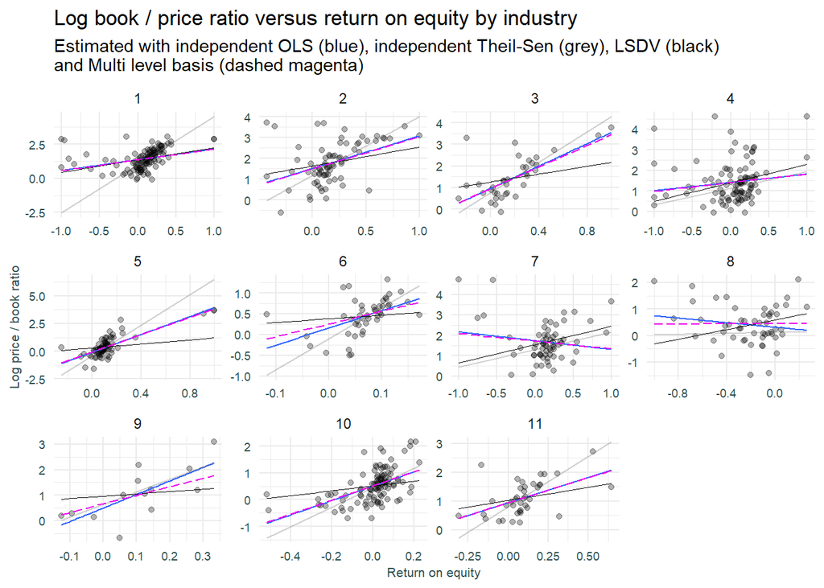

```r
# Mixed effects model with fixed and random intercept
lme_1 <- lmer(log_pb ~ roe + (1 + roe | sector), data = data)

# Add predicted values for line in scatter plot
data$lme1_pred <- predict(lme_1)

p3 <- p2 +
  geom_line(aes(x = roe, y = lme1_pred), data = data, size = 0.4, color = 'magenta2', linetype = 'longdash') + #darkorchid3
  labs(subtitle = 'Estimated with independent OLS (blue), independent Theil-Sen (grey), LSDV (black) \nand Multi level basis (dashed magenta)') +
  facet_wrap(~reorder(sector, as.numeric(sector)), ncol = 4, scales = 'free')

p3
```

And the the coefficients.

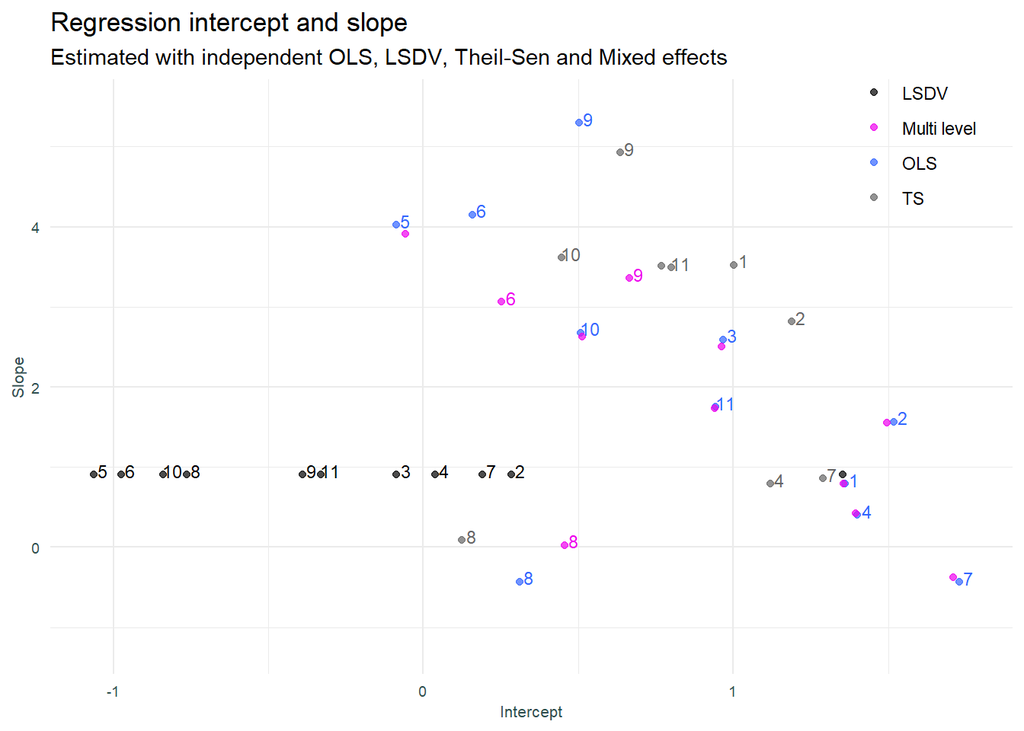

```r
# Plot coefficients - add coefficients to existing plot
# CHANGE SOURCE TO MODEL
lme1_coefs = data.frame(
  sector = as.factor(rownames(ranef(lme_1)$sector)),
  intercept = unname(coef(lme_1)$sector['(Intercept)']),  # works only for single grouping variable
  slope = unname(coef(lme_1)$sector['roe']),              # works only for single grouping variable
  source = rep('Multi level', 11)
  )

model_coefs_all <- bind_rows(model_coefs_all, lme1_coefs)

model_coefs_all %>%
  filter(source %in% c('OLS','TS','LSDV','Multi level')) %>%
  ggplot(aes(x = intercept, y = slope, colour = source)) +
  geom_point(alpha = 0.7) + ylim(-1.25, 5.5) +
  geom_text(aes(label = sector), nudge_x = 0.03, nudge_y = 0.05, check_overlap = TRUE, show.legend = FALSE, size = 3) +
  labs(
    title = 'Regression intercept and slope',
    subtitle = 'Estimated with independent OLS, LSDV, Theil-Sen and Mixed effects',
    x = 'Intercept',
    y = 'Slope'
  ) +
  def_theme1 +
  scale_color_manual(values=c("OLS"="#3366FF", "TS"="grey40", "LSDV"="black", "Multi level"="magenta2"))
```

Note that the model as defined estimates a correlation between the intercept and slope for each sector.

## Bayesian approach

Next, we estimate the multi level model using a bayesian approach. This will allow for the specification of priors for both the slope and intercept coefficients, and also the correlation between those coefficients. An appropriately specified prior should enforce more shrinkage (remember we are encoding our domain knowledge here, and assuming a negative relation between P/B ratio and ROE does not make sense).

The intercepts is defined as the outcome (log_pb) when the predictor (roe) is zero. When the predictor variable is standardised like we have just done, it’s mean is zero. So what is a reasonable expectation of the log_bp when roe is at it’s mean? Luckily the second plot above uses the standardised ROE and we can see this is associated with a log_pb of circa 1.25. That converts to a P/B ratio of around 3.5 (the exponent of 1.25).

```r
# Data in Rethinking / McElreath format
d <- list(
  log_pb = data$log_pb,
  roe    = data$roe,
  vol    = data$vol_ari_60d,
  sector = data$sector,
  n      = nrow(data)
  )

set.seed(123)
bayes1 <- ulam(
  alist(

    # Response distribution
    log_pb ~ normal(mu, sigma),

    # Linear model
    mu <- a_sector[sector] + b_sector[sector] * roe,

    # Variance co-variance matrix prior for intercept and slope
    c(a_sector, b_sector)[sector] ~ multi_normal(c(a, b), Rho, sigma_sector),
    a ~ normal(1.25, 1),                         # prior for average intercept
    b ~ normal(1, 1.5),                          # prior for average slope
    sigma_sector ~ exponential(1),
    sigma ~ exponential(1),                      # prior for residual standard deviation of response dist.
    Rho ~ lkj_corr(2)                            # prior for correlation matrix
  ),
  data = d,
  cores = 4
  )
# Coefficients
bayes1_coef_tbl <- coeftab(bayes1)
bayes1_coef <- data.frame(coef = row.names(bayes1_coef_tbl@coefs), value = bayes1_coef_tbl@coefs, row.names = NULL)
bayes1_coef$t <- substr(bayes1_coef$coef, 1, 1)
bayes1_coef$s <- as.integer(gsub("\\D", "", bayes1_coef$coef))

bayes1_coef1 <- data.frame(
  sector = as.factor(bayes1_coef[!is.na(bayes1_coef$s) & bayes1_coef$t == 'b', ]$s),
  intercept = bayes1_coef[!is.na(bayes1_coef$s) & bayes1_coef$t == 'a', ]$bayes1 + bayes1_coef[bayes1_coef$coef == 'a', ]$bayes1 * 0,
  slope = bayes1_coef[!is.na(bayes1_coef$s) & bayes1_coef$t == 'b', ]$bayes1 + bayes1_coef[bayes1_coef$coef == 'b', ]$bayes1 * 0, # included fixed effect / popn level param
  source = 'Bayes normal'
  )

model_coefs_all <- bind_rows(model_coefs_all, bayes1_coef1)


# Predictions
bayes1_pred_samples <- link(bayes1, data = d)
data$bayes1_pred <- apply(bayes1_pred_samples, 2, mean)
```

Here is the plot of the regression.

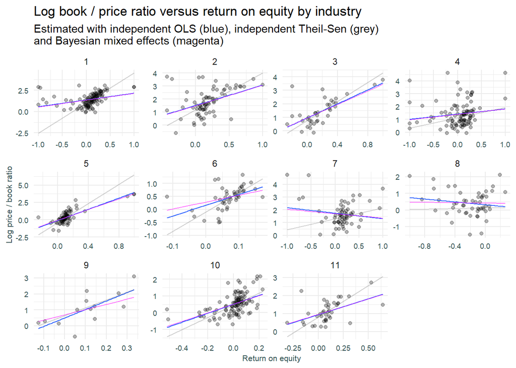

```r
# Plot
p4 <- p1 +
  geom_line(aes(x = roe, y = bayes1_pred), data = data, size = 0.3, colour = 'magenta') +
  labs(subtitle = 'Estimated with independent OLS (blue), independent Theil-Sen (grey) \nand Bayesian mixed effects (magenta)') +
  def_theme1

p4
```

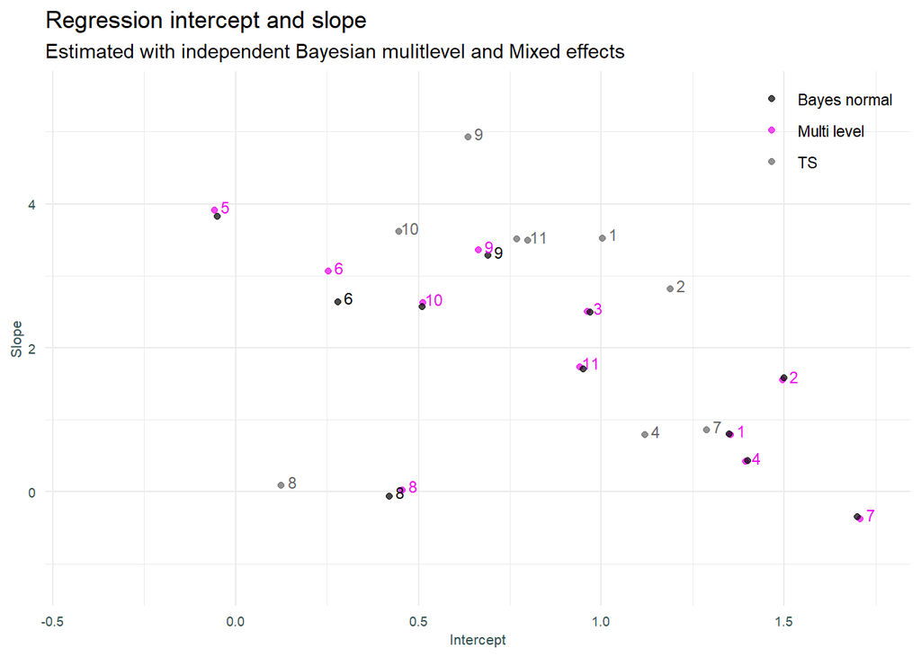

```r
model_coefs_all %>%
  filter(source %in% c('Bayes normal', 'Multi level', 'TS')) %>%
  ggplot(aes(x = intercept, y = slope, colour = source)) +
  geom_point(alpha = 0.7) + ylim(-1.25, 5.5) +
  geom_text(aes(label = sector), nudge_x = 0.03, nudge_y = 0.05, check_overlap = TRUE, show.legend = FALSE, size = 3) +
  labs(
    title = 'Regression intercept and slope',
    subtitle = 'Estimated with independent Bayesian mulitlevel and Mixed effects',
    x = 'Intercept',
    y = 'Slope'
  ) +
  def_theme1 +
  scale_color_manual(values=c("Bayes normal"="black", "TS"="grey40", "Multi level"="magenta2"))
```

```r
# Data in Rethinking / McElreath format
set.seed(123)
bayes2 <- ulam(
  alist(

    # Response distribution
    log_pb ~ dstudent(nu , mu, sigma),

    # Linear model
    mu <- a_sector[sector] + b_sector[sector] * roe,

    # Variance co-variance matrix prior for intercept and slope
    c(a_sector, b_sector)[sector] ~ multi_normal(c(a, b), Rho, sigma_sector),
    a ~ normal(1.25, 1),                         # prior for average intercept
    b ~ normal(1, 1.5),                          # prior for average slope
    nu ~ gamma(2, 0.1),                         # brms default prior
    sigma_sector ~ exponential(1),
    sigma ~ exponential(1),                      # prior for residual standard deviation of response dist.
    Rho ~ lkj_corr(2)                            # prior for correlation matrix
  ),
  data = d,
  cores = 4
  )
# Coefficients
bayes2_coef_tbl <- coeftab(bayes2)
bayes2_coef <- data.frame(coef = row.names(bayes2_coef_tbl@coefs), value = bayes2_coef_tbl@coefs, row.names = NULL)
bayes2_coef$t <- substr(bayes2_coef$coef, 1, 1)
bayes2_coef$s <- as.integer(gsub("\\D", "", bayes2_coef$coef))

bayes2_coef1 <- data.frame(
  sector = as.factor(bayes2_coef[!is.na(bayes2_coef$s) & bayes2_coef$t == 'b', ]$s),
  intercept = bayes2_coef[!is.na(bayes2_coef$s) & bayes2_coef$t == 'a', ]$bayes2 + bayes2_coef[bayes2_coef$coef == 'a', ]$bayes2 * 0,
  slope = bayes2_coef[!is.na(bayes2_coef$s) & bayes2_coef$t == 'b', ]$bayes2 + bayes2_coef[bayes2_coef$coef == 'b', ]$bayes2 * 0, # included fixed effect / popn level param
  source = 'Bayes student'
  )

model_coefs_all <- bind_rows(model_coefs_all, bayes2_coef1)


# Predictions
bayes2_pred_samples <- link(bayes2, data = d)
data$bayes2_pred <- apply(bayes2_pred_samples, 2, mean)
```

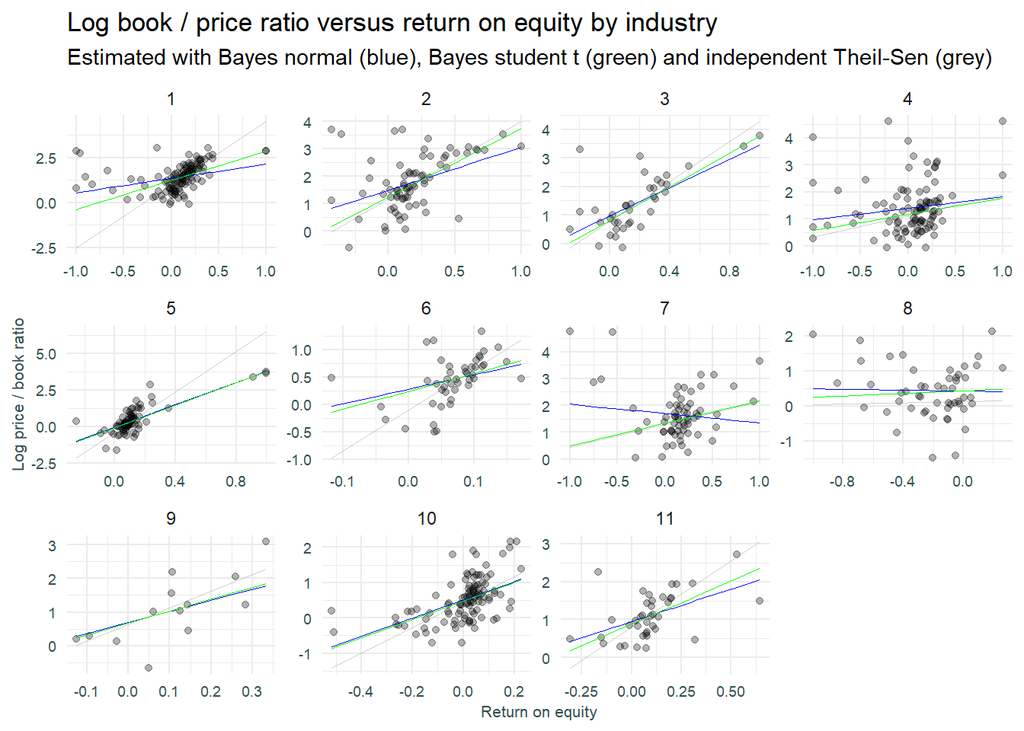

```r
# Plot
p5 <- data %>%
  ggplot(aes(x = roe, y = log_pb)) +
  facet_wrap(~reorder(sector, as.numeric(sector)), ncol = 4, scales = 'free') +
  geom_point(alpha = 0.3) +
  geom_line(aes(x = roe, y = bayes1_pred), data = data, size = 0.3, colour = 'blue') +
  geom_line(aes(x = roe, y = bayes2_pred), data = data, size = 0.3, colour = 'green') +
  geom_segment(
    aes(x = x_min, xend = x_max, y = y_min, yend = y_max),
    alpha = 0.3,
    data = filter(model_coefs, date_stamp == as.Date('2021-06-30')),
    colour = 'grey40', size = 0.3
  ) +
  labs(
    title = 'Log book / price ratio versus return on equity by industry',
    subtitle = 'Estimated with Bayes normal (blue), Bayes student t (green) and independent Theil-Sen (grey)',
    x = 'Return on equity',
    y = 'Log price / book ratio'
  ) +
  def_theme1

p5
```

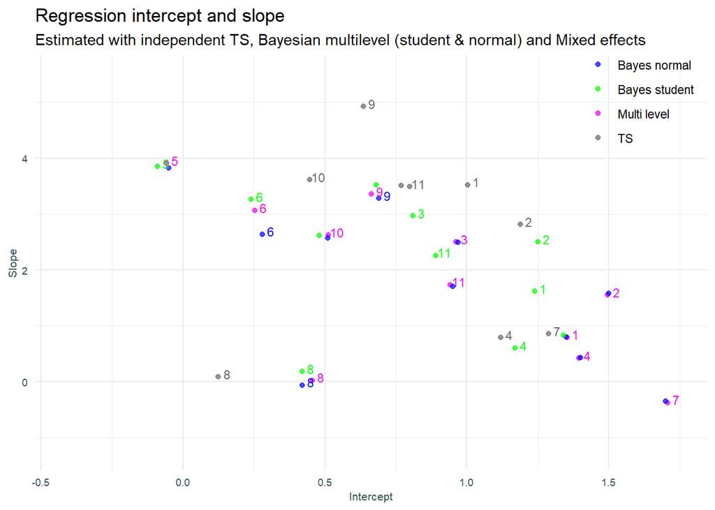

```r
model_coefs_all %>%
  filter(source %in% c('Bayes normal','Bayes student','Multi level', 'TS')) %>%
  ggplot(aes(x = intercept, y = slope, colour = source)) +
  geom_point(alpha = 0.7) + ylim(-1.25, 5.5) +
  geom_text(aes(label = sector), nudge_x = 0.03, nudge_y = 0.05, check_overlap = TRUE, show.legend = FALSE, size = 3) +
  labs(
    title = 'Regression intercept and slope',
    subtitle = 'Estimated with independent TS, Bayesian multilevel (student & normal) and Mixed effects',
    x = 'Intercept',
    y = 'Slope'
  ) +
  def_theme1 +
  scale_color_manual(values=c("Bayes normal"="blue", "Bayes student"="green", "TS"="grey40", "Multi level"="magenta2"))
```

## Bayesian model with measurement error

Model per McElreath p 493.

```r
# Data in Rethinking / McElreath format
set.seed(123)
bayes3 <- ulam(
  alist(

    # Response distribution
    log_pb ~ dstudent(nu, log_pb_t, sigma),
    vector[n]:log_pb_t ~ dstudent(nu_t, mu, sigma),

    # Linear model
    mu <- a_sector[sector] + b_sector[sector] * roe,

    # Variance co-variance matrix prior for intercept and slope
    c(a_sector, b_sector)[sector] ~ multi_normal(c(a, b), Rho, sigma_sector),
    a ~ normal(1.25, 1),                         # prior for average intercept
    b ~ normal(1, 1.5),                          # prior for average slope
    nu ~ gamma(2, 0.1),                         # brms default prior
    nu_t ~ gamma(2, 0.1),                         # brms default prior
    sigma_sector ~ exponential(1),
    sigma ~ exponential(1),                      # prior for residual standard deviation of response dist.
    Rho ~ lkj_corr(2)                            # prior for correlation matrix
  ),
  data = d,
  cores = 4
  )
# Coefficients
bayes3_coef_tbl <- coeftab(bayes3)
bayes3_coef <- data.frame(coef = row.names(bayes3_coef_tbl@coefs), value = bayes3_coef_tbl@coefs, row.names = NULL)
bayes3_coef$t <- substr(bayes3_coef$coef, 1, 1)
bayes3_coef$s <- as.integer(gsub("\\D", "", bayes3_coef$coef))

bayes3_coef1 <- data.frame(
  sector = as.factor(bayes3_coef[!is.na(bayes3_coef$s) & bayes3_coef$t == 'b', ]$s),
  intercept = bayes3_coef[!is.na(bayes3_coef$s) & bayes3_coef$t == 'a', ]$bayes3 + bayes3_coef[bayes3_coef$coef == 'a', ]$bayes3 * 0,
  slope = bayes3_coef[!is.na(bayes3_coef$s) & bayes3_coef$t == 'b', ]$bayes3 + bayes3_coef[bayes3_coef$coef == 'b', ]$bayes3 * 0, # included fixed effect / popn level param
  source = 'Bayes student me'
  )

model_coefs_all <- bind_rows(model_coefs_all, bayes3_coef1)


# Predictions
bayes3_pred_samples <- link(bayes3, data = d)
data$bayes3_pred <- apply(bayes3_pred_samples, 2, mean)
```

Scatter plots

[figure not shown]

```r
p6 <- p5 +
  geom_line(aes(x = roe, y = bayes3_pred), data = data, size = 0.3, colour = 'blue') +
  labs(
    title = 'Log book / price ratio versus return on equity by industry',
    subtitle = 'Estimated with Bayes normal (blue), Bayes student t (green) and independent Theil-Sen (grey)',
    x = 'Return on equity',
    y = 'Log price / book ratio'
  )

p6
```

Coefficient plots

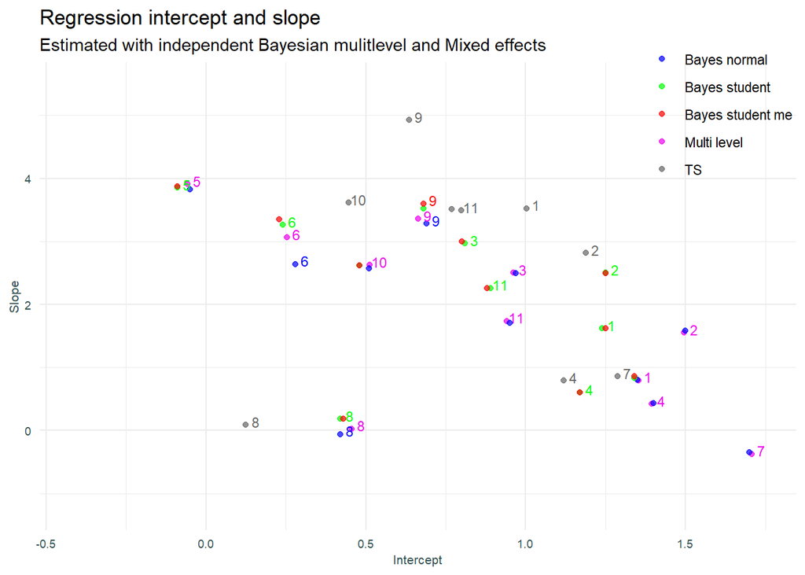

```r
model_coefs_all %>%
  filter(source %in% c('Bayes normal','Bayes student','Bayes student me','Multi level', 'TS')) %>%
  ggplot(aes(x = intercept, y = slope, colour = source)) +
  geom_point(alpha = 0.7) + ylim(-1.25, 5.5) +
  geom_text(aes(label = sector), nudge_x = 0.03, nudge_y = 0.05, check_overlap = TRUE, show.legend = FALSE, size = 3) +
  labs(
    title = 'Regression intercept and slope',
    subtitle = 'Estimated with independent Bayesian mulitlevel and Mixed effects',
    x = 'Intercept',
    y = 'Slope'
  ) +
  def_theme1 +
  scale_color_manual(values=c("Bayes normal"="blue", "Bayes student"="green", "Bayes student me"="red", "TS"="grey40", "Multi level"="magenta2"))
```

## Appendix

### Model in `brms`

```r
b1 <-
  brm(data = d,
      family = gaussian,
      log_pb ~ 1 + roe + (1 + roe | sector),
      prior = c(prior(normal(5, 2), class = Intercept),
                prior(normal(-1, 0.5), class = b),
                prior(exponential(1), class = sd),
                prior(exponential(1), class = sigma),
                prior(lkj(2), class = cor)),
      iter = 2000, warmup = 1000, chains = 4, cores = 4,
  )

summary(b1)
```

```
##  Family: gaussian
##   Links: mu = identity; sigma = identity
## Formula: log_pb ~ 1 + roe + (1 + roe | sector)
##    Data: d (Number of observations: 732)
##   Draws: 4 chains, each with iter = 2000; warmup = 1000; thin = 1;
##          total post-warmup draws = 4000
##
## Group-Level Effects:
## ~sector (Number of levels: 11)
##                    Estimate Est.Error l-95% CI u-95% CI Rhat Bulk_ESS Tail_ESS
## sd(Intercept)          0.69      0.19     0.42     1.17 1.01     1010     1691
## sd(roe)                2.21      0.63     1.22     3.64 1.00     1058     1693
## cor(Intercept,roe)    -0.48      0.28    -0.88     0.17 1.00      719     1246
##
## Population-Level Effects:
##           Estimate Est.Error l-95% CI u-95% CI Rhat Bulk_ESS Tail_ESS
## Intercept     1.17      0.27     0.68     1.76 1.00      602     1141
## roe          -0.01      0.50    -0.99     0.93 1.00     1536     2259
##
## Family Specific Parameters:
##       Estimate Est.Error l-95% CI u-95% CI Rhat Bulk_ESS Tail_ESS
## sigma     0.74      0.02     0.70     0.78 1.00     4807     3327
##
## Draws were sampled using sampling(NUTS). For each parameter, Bulk_ESS
## and Tail_ESS are effective sample size measures, and Rhat is the potential
## scale reduction factor on split chains (at convergence, Rhat = 1).
```

```r
coef(b1)
```

```
## $sector
## , , Intercept
##
##       Estimate  Est.Error         Q2.5     Q97.5
## 1   1.35871535 0.06777190  1.226557642 1.4945577
## 2   1.50843277 0.10506530  1.306483908 1.7162566
## 3   0.98348655 0.14475894  0.697390844 1.2706008
## 4   1.39552702 0.07427234  1.251805755 1.5433709
## 5  -0.04642854 0.09613607 -0.234460459 0.1438434
## 6   0.30285915 0.15156185  0.001986589 0.6003983
## 7   1.71189541 0.10005616  1.517368165 1.9086931
## 8   0.38927391 0.13279165  0.123760633 0.6434873
## 9   0.70492261 0.24642387  0.201902204 1.1771664
## 10  0.51327367 0.07014804  0.376989019 0.6517903
## 11  0.95575317 0.13322872  0.702517678 1.2156094
##
## , , roe
##
##      Estimate Est.Error        Q2.5     Q97.5
## 1   0.7682366 0.2229229  0.34323628 1.2063645
## 2   1.5298048 0.3330324  0.88698692 2.1854114
## 3   2.4497033 0.4710653  1.53322925 3.3724770
## 4   0.3910082 0.2180053 -0.03364453 0.8235281
## 5   3.8248652 0.4470142  2.95075088 4.7074567
## 6   2.3584876 1.5104569 -0.56129671 5.4785378
## 7  -0.4166598 0.2785248 -0.96801881 0.1341611
## 8  -0.2200975 0.3975417 -0.98791859 0.5563387
## 9   3.3025181 1.3473767  0.80401387 6.0736917
## 10  2.5052712 0.5655013  1.37905238 3.6024112
## 11  1.5834789 0.6667092  0.28199331 2.8865648
```

## References

[1] Harrison XA, Donaldson L, Correa-Cano ME, Evans J, Fisher DN, Goodwin CED, Robinson BS, Hodgson DJ, Inger R. 2018. A brief introduction to mixed effects modelling and multi-model inference in ecology. PeerJ 6:e4794 https://doi.org/10.7717/peerj.4794  
[2] Paul-Christian Bürkner. Advanced Bayesian Multilevel Modeling with the R Package brms. 2018  
[3] Green, Brice and Thomas, Samuel, Inference and Prediction of Stock Returns using Multilevel Models (August 31, 2019). Available at SSRN: https://ssrn.com/abstract=3411358 or http://dx.doi.org/10.2139/ssrn.3411358

Mixed effects models using lme4 lme4 manual:- https://lme4.r-forge.r-project.org/book/

lme4 manual:- https://www.chalmers.se/sv/institutioner/math/forskning/forskarutbildning/forskarutbildning-matematisk-statistik/forskarutbildningskurser-matematisk-statistik/Documents/bates_manual.pdf

vignette:- https://cran.r-project.org/web/packages/lme4/vignettes/lmer.pdf

Doug Bates pres:- http://pages.stat.wisc.edu/~bates/UseR2008/WorkshopD.pdf

Example to find lme4 predict coefficients:- https://stats.stackexchange.com/questions/174203/predict-function-for-lmer-mixed-effects-models/174227

Various syntax notes:- https://yury-zablotski.netlify.app/post/mixed-effects-models-2/

Syntax cheat sheet:- https://stats.stackexchange.com/questions/13166/rs-lmer-cheat-sheet

Sweep function:- https://stackoverflow.com/questions/3444889/how-to-use-the-sweep-function

Plot reference:-https://www.tjmahr.com/plotting-partial-pooling-in-mixed-effects-models/

Model diagnostics:- https://www.ssc.wisc.edu/sscc/pubs/MM/MM_DiagInfer.html

Shrinkage & correlation:- http://doingbayesiandataanalysis.blogspot.com/2019/07/shrinkage-in-hierarchical-models-random.html

Diagnostics - https://www.ssc.wisc.edu/sscc/pubs/MM/MM_DiagInfer.html

https://bayesiancomputationbook.com/markdown/chp_04.html#mixing-group-and-common-parameters

https://www.cbssports.com/mlb/news/mlb-analytics-guru-who-could-be-the-next-nate-silver-has-a-revolutionary-new-stat/

https://www.baseballprospectus.com/news/article/26195/prospectus-feature-introducing-deserved-run-average-draand-all-its-friends/

https://www.baseballprospectus.com/news/article/26196/prospectus-feature-dra-an-in-depth-discussion/

Robust bayesian regression - https://solomonkurz.netlify.app/post/2019-02-02-robust-linear-regression-with-student-s-t-distribution/